# Deep_Neural_Network_Bank_Churn_Prediction

### Problem Statement

Businesses like banks that provide service have to worry about the problem of 'Churn' i.e. customers leaving and joining another service provider. It is important to understand which aspects of the service influence a customer's decision in this regard. Management can concentrate efforts on the improvement of service, keeping in mind these priorities.

### Objective

Given a Bank customer, build a neural network-based classifier that can determine whether they will leave or not in the next 6 months.

### Data Description

The case study is from an open-source dataset from Kaggle. The dataset contains 10,000 sample points with 14 distinct features such as CustomerId, CreditScore, Geography, Gender, Age, Tenure, Balance, etc.

### Data Dictionary

- **CustomerId:** Unique ID which is assigned to each customer
- **Surname:** Last name of the customer
- **CreditScore:** Credit history of the customer.
- **Geography:** A customer’s location
- **Gender:** Gender of the customer
- **Age:** Age of the customer
- **Tenure:** Number of years for which the customer has been with the bank
- **NumOfProducts:** Number of products that a customer has purchased through the bank.
- **Balance:** Account balance
- **HasCrCard:** Categorical variable that decides whether the customer has a credit card or not.
- **EstimatedSalary:** Estimated salary
- **isActiveMember:** Categorical variable that decides whether the customer is an active member of the bank or not ( Active member in the sense, using bank products regularly, making transactions, etc )
- **Exited:** Categorical variable that decides whether the customer left the bank within six months or not. It can take two values:
  - 0=No ( Customer did not leave the bank )
  - 1=Yes ( Customer left the bank )
- **Importing Libraries**
- **Initial Data Overview & Cleaning**
- **Exploratory Data Analysis**
  - Univariate Data Analysis
  - Target Variable Analysis
- **EDA and Data Cleaning Summary**
  - Data Cleaning Summary
  - EDA Summary
- **Data Pre-processing**
  - Data Pre-Processing Summary
  - Model Evaluation Criterion
- **Model Building**
- **Model Performance Improvement**
  - Model 1
  - SMOTE and RUS (Base Model)
  - Model 2
    - Exploring Adam and RMSprop Optimizers
- **Model Performance Evaluation**
- **Conclusion**
  - Model Building
  - Key Insights

### Importing Libraries

```python
#!pip install keras-tuner
```

```python
# Libraries to help with reading and manipulating data
import numpy as np
import pandas as pd
# libaries to help with data visualization
import matplotlib.pyplot as plt
import seaborn as sns
from matplotlib import pyplot

# Setting visualization and data manipulation options
sns.set_theme(color_codes=True,
              style="darkgrid",
              context="talk",
              palette="hls",
              font_scale=0.75
)
%matplotlib inline
pd.set_option("display.float_format", lambda x: "%.3f" % x)
pd.set_option("display.max_columns", None)
pd.set_option("display.max_rows", 200)

# Library to split data
from sklearn.model_selection import train_test_split
# library to import to standardize the data
from sklearn.preprocessing import StandardScaler
# Libary for viewing confusion matrix
from sklearn.metrics import roc_curve
from sklearn.metrics import confusion_matrix
from sklearn import metrics
#Importing classback API
from keras import callbacks
# Importing tensorflow library
import tensorflow as tf
# importing different functions to build models
from tensorflow.keras.layers import Dense, Dropout,InputLayer
from tensorflow.keras.models import Sequential
# Importing Batch Normalization
from keras.layers import BatchNormalization
# Importing backend
from tensorflow.keras import backend
# Importing shffule
from random import shuffle
from keras.callbacks import ModelCheckpoint
# For model tuning
from tensorflow import keras
from tensorflow.keras import layers
import keras_tuner
from keras_tuner.tuners import RandomSearch
from sklearn.model_selection import RandomizedSearchCV
from keras_tuner.tuners import BayesianOptimization
# Importing optimizers
from tensorflow.keras.optimizers import Adam
from tensorflow.keras.optimizers import RMSprop
```

### Initial Data Overview & Cleaning

```python
# Mounting gdrive
from google.colab import drive
drive.mount('/content/gdrive')

# Importing the dataset
data = pd.read_csv('/content/gdrive/MyDrive/Colab Notebooks/AIML - PGP/Neural Networks/Project/Churn.csv')
# Preserving the original data by creating a copy
df = data.copy()

# Initial view of the data
print(f"There are {df.shape[0]} rows and {df.shape[1]} columns.")
np.random.seed(1)
df.sample(n=10)
```

```
There are 10000 rows and 14 columns.
```

|  | RowNumber | CustomerId | Surname | CreditScore | Geography | Gender | Age | Tenure | Balance | NumOfProducts | HasCrCard | IsActiveMember | EstimatedSalary | Exited |
| --- | --- | --- | --- | --- | --- | --- | --- | --- | --- | --- | --- | --- | --- | --- |
| 9953 | 9954 | 15655952 | Burke | 550 | France | Male | 47 | 2 | 0.000 | 2 | 1 | 1 | 97057.280 | 0 |
| 3850 | 3851 | 15775293 | Stephenson | 680 | France | Male | 34 | 3 | 143292.950 | 1 | 1 | 0 | 66526.010 | 0 |
| 4962 | 4963 | 15665088 | Gordon | 531 | France | Female | 42 | 2 | 0.000 | 2 | 0 | 1 | 90537.470 | 0 |
| 3886 | 3887 | 15720941 | Tien | 710 | Germany | Male | 34 | 8 | 147833.300 | 2 | 0 | 1 | 1561.580 | 0 |
| 5437 | 5438 | 15733476 | Gonzalez | 543 | Germany | Male | 30 | 6 | 73481.050 | 1 | 1 | 1 | 176692.650 | 0 |
| 8517 | 8518 | 15671800 | Robinson | 688 | France | Male | 20 | 8 | 137624.400 | 2 | 1 | 1 | 197582.790 | 0 |
| 2041 | 2042 | 15709846 | Yeh | 840 | France | Female | 39 | 1 | 94968.970 | 1 | 1 | 0 | 84487.620 | 0 |
| 1989 | 1990 | 15622454 | Zaitsev | 695 | Spain | Male | 28 | 0 | 96020.860 | 1 | 1 | 1 | 57992.490 | 0 |
| 1933 | 1934 | 15815560 | Bogle | 666 | Germany | Male | 74 | 7 | 105102.500 | 1 | 1 | 1 | 46172.470 | 0 |
| 9984 | 9985 | 15696175 | Echezonachukwu | 602 | Germany | Male | 35 | 7 | 90602.420 | 2 | 1 | 1 | 51695.410 | 0 |

```python
# Checking for duplicated data
df.duplicated().sum()
```

```
0
```

There is no duplicated information within the data set

```python
# Checking for missing data
df.isnull().sum()
```

```
RowNumber          0
CustomerId         0
Surname            0
CreditScore        0
Geography          0
Gender             0
Age                0
Tenure             0
Balance            0
NumOfProducts      0
HasCrCard          0
IsActiveMember     0
EstimatedSalary    0
Exited             0
dtype: int64
```

There is no missing information within the data set

```python
# General overview of the dataset
df.info()
```

```
<class 'pandas.core.frame.DataFrame'>
RangeIndex: 10000 entries, 0 to 9999
Data columns (total 14 columns):
 #   Column           Non-Null Count  Dtype
---  ------           --------------  -----
 0   RowNumber        10000 non-null  int64
 1   CustomerId       10000 non-null  int64
 2   Surname          10000 non-null  object
 3   CreditScore      10000 non-null  int64
 4   Geography        10000 non-null  object
 5   Gender           10000 non-null  object
 6   Age              10000 non-null  int64
 7   Tenure           10000 non-null  int64
 8   Balance          10000 non-null  float64
 9   NumOfProducts    10000 non-null  int64
 10  HasCrCard        10000 non-null  int64
 11  IsActiveMember   10000 non-null  int64
 12  EstimatedSalary  10000 non-null  float64
 13  Exited           10000 non-null  int64
dtypes: float64(2), int64(9), object(3)
memory usage: 1.1+ MB
```

Observations:

- Majority of columns are numerical dtype
- Customer ID and Surname can be dropped since they are unique identifiers and will not contribute to the analysis of model building
- Row Number can also be dropped as it is just a superfluous index
- Column names are slightly obtuse, they will need to be reformmated
- Exited is our target variable
- Some columns are actually categorical in nature, not numerical. We'll need to convert their dtype before continuing analysis.

```python
# Dropping unneeded columns
df.drop(['CustomerId', 'Surname', 'RowNumber'], axis=1, inplace=True)

# Renaming columns
df.rename(columns={'CreditScore': 'Credit',
                   'Geography': 'Location',
                   'NumOfProducts': 'Products',
                   'HasCrCard': 'CreditCard',
                   'IsActiveMember': 'Active',
                   'EstimatedSalary': 'Income'},
          inplace=True)

# Initiating lists for categorical and numerical variables
num_cols = ['Credit', 'Balance',
            'Income', 'Age']
cat_cols = ['Location', 'Gender', 'Tenure',
            'Products', 'CreditCard', 'Active',
            'Exited']

# Converting all columns to correct dtype
df[num_cols] = df[num_cols].astype('int64')
df[cat_cols] = df[cat_cols].astype('category')

# Verifying Results
df.info()
```

```
<class 'pandas.core.frame.DataFrame'>
RangeIndex: 10000 entries, 0 to 9999
Data columns (total 11 columns):
 #   Column      Non-Null Count  Dtype
---  ------      --------------  -----
 0   Credit      10000 non-null  int64
 1   Location    10000 non-null  category
 2   Gender      10000 non-null  category
 3   Age         10000 non-null  int64
 4   Tenure      10000 non-null  category
 5   Balance     10000 non-null  int64
 6   Products    10000 non-null  category
 7   CreditCard  10000 non-null  category
 8   Active      10000 non-null  category
 9   Income      10000 non-null  int64
 10  Exited      10000 non-null  category
dtypes: category(7), int64(4)
memory usage: 382.2 KB
```

### Exploratory Data Analysis

**Univariate Data Analysis**

```python
# Function to plot a boxplot and a histogram along the same scale.
def hist_box(data, feature, figsize=(12, 7), kde=False, bins=None):
    """
    Boxplot and histogram combined

    data: dataframe
    feature: dataframe column
    figsize: size of figure (default (12,7))
    kde: whether to the show density curve (default False)
    bins: number of bins for histogram (default None)
    """
    f2, (ax_box2, ax_hist2) = plt.subplots(
        nrows=2,  # Number of rows of the subplot grid= 2
        sharex=True,  # x-axis will be shared among all subplots
        gridspec_kw={"height_ratios": (0.25, 0.75)},
        figsize=figsize,
    )  # creating the 2 subplots
    sns.boxplot(
        data=data, x=feature, ax=ax_box2, showmeans=True, color="violet"
    )  # boxplot will be created and a star will indicate the mean value of the column
    sns.histplot(
        data=data, x=feature, kde=kde, ax=ax_hist2, bins=bins, palette="winter"
    ) if bins else sns.histplot(
        data=data, x=feature, kde=kde, ax=ax_hist2
    )  # For histogram
    ax_hist2.axvline(
        data[feature].mean(), color="green", linestyle="--"
    )  # Add mean to the histogram
    ax_hist2.axvline(
        data[feature].median(), color="black", linestyle="-"
    )  # Add median to the histogram
```

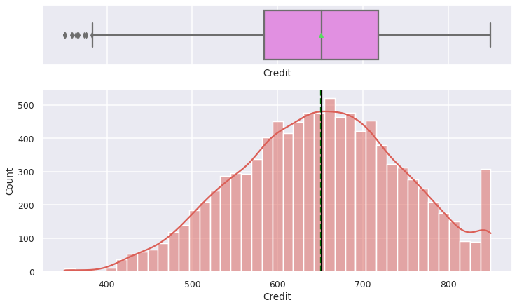

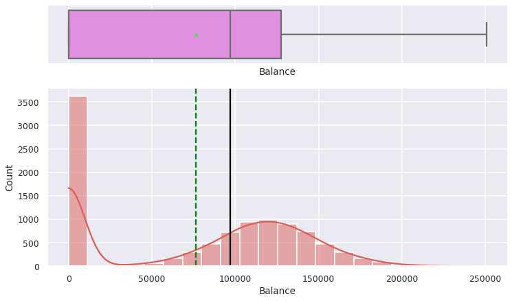

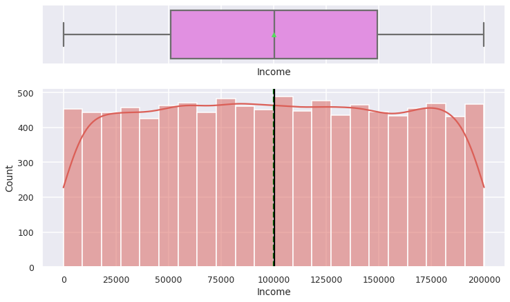

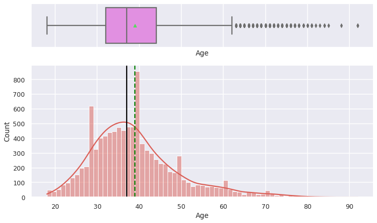

```python
# Plotting distributions of numerical data
for i in df[num_cols]:
  hist_box(data=df, feature=i, kde=True)
```

Observations:

- Credit is normally distributed, range appears nominal
- Balance is normally distributed with a range from 0 to 250k
  - A significant portion of customers have nothing in their bank account balance
- Suprisingly, Income is uniformally distributed with a range from 0 to 200k
- Age is normally distributed with a slight right tail and a range of 20-90+

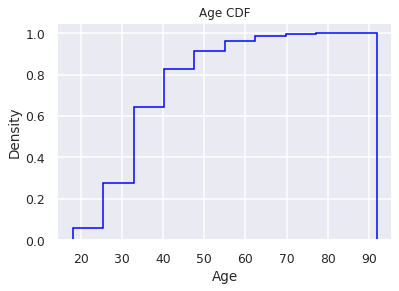

```python
# Plotting Cumulative Distributions of Numerical Data
plt.hist(
    data=df,
    x="Age",
    density=True,
    cumulative=True,
    label="CDF",
    histtype="step",
    color="blue",
)
plt.xlabel("Age")
plt.ylabel("Density")
plt.title("Age CDF", fontsize=12)
```

80% of customers are under the age of 50

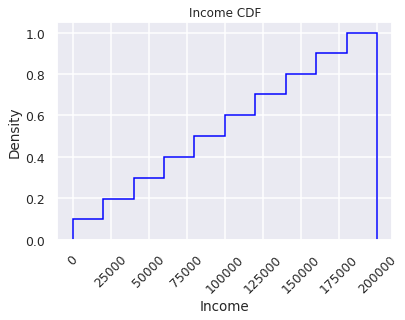

```python
plt.hist(
    data=df,
    x="Income",
    density=True,
    cumulative=True,
    label="CDF",
    histtype="step",
    color="blue",
)
plt.xticks(rotation = 45)
plt.xlabel("Income")
plt.ylabel("Density")
plt.title("Income CDF", fontsize=12)
```

70% of customers make below 125k annually

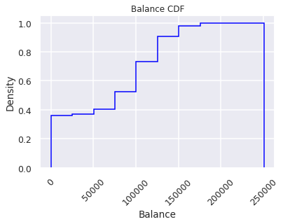

```python
plt.hist(
    data=df,
    x="Balance",
    density=True,
    cumulative=True,
    label="CDF",
    histtype="step",
    color="blue",
)
plt.xticks(rotation = 45)
plt.xlabel("Balance")
plt.ylabel("Density")
plt.title("Balance CDF", fontsize=12)
```

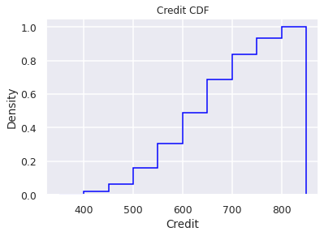

```python
plt.hist(
    data=df,
    x="Credit",
    density=True,
    cumulative=True,
    label="CDF",
    histtype="step",
    color="blue",
)
plt.xlabel("Credit")
plt.ylabel("Density")
plt.title("Credit CDF", fontsize=12)
```

```python
# Function to create labeled barplots
def labeled_barplot(data, feature, perc=False, n=None):
    """
    Barplot with percentage at the top

    data: dataframe
    feature: dataframe column
    perc: whether to display percentages instead of count (default is False)
    n: displays the top n category levels (default is None, i.e., display all levels)
    """

    total = len(data[feature])  # length of the column
    count = data[feature].nunique()
    if n is None:
        plt.figure(figsize=(count + 1, 5))
    else:
        plt.figure(figsize=(n + 1, 5))

    plt.xticks(rotation=90, fontsize=15)
    ax = sns.countplot(
        data=data,
        x=feature,
        palette="Paired",
        order=data[feature].value_counts().index[:n].sort_values(),
    )

    for p in ax.patches:
        if perc == True:
            label = "{:.1f}%".format(
                100 * p.get_height() / total
            )  # percentage of each class of the category
        else:
            label = p.get_height()  # count of each level of the category

        x = p.get_x() + p.get_width() / 2  # width of the plot
        y = p.get_height()  # height of the plot

        ax.annotate(
            label,
            (x, y),
            ha="center",
            va="center",
            size=12,
            xytext=(0, 5),
            textcoords="offset points",
        )  # annotate the percentage

    plt.show()  # show the plot
```

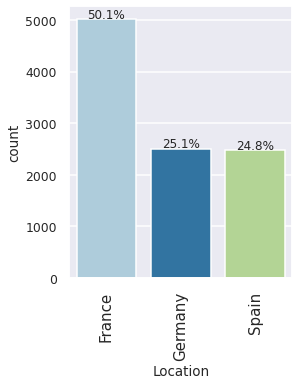

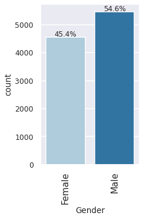

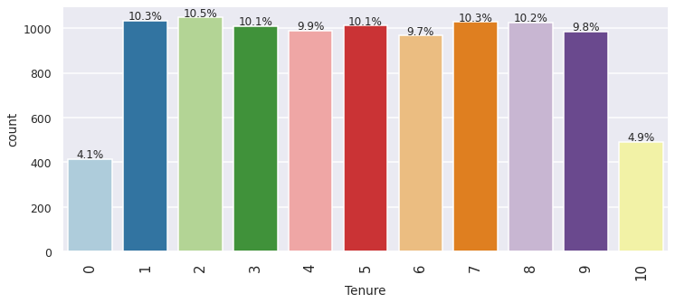

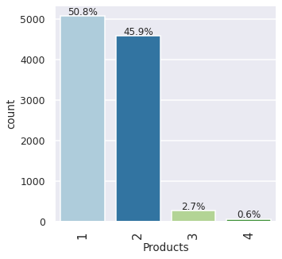

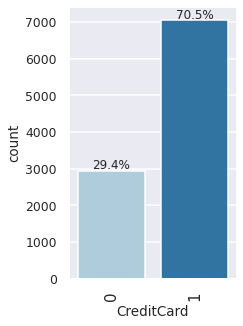

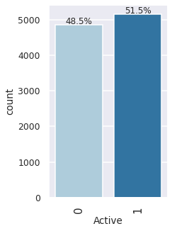

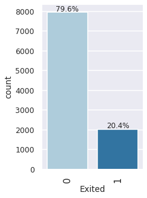

```python
for i in df[cat_cols]:
  labeled_barplot(data=df, feature=i, perc=True)
```

Observations:

- 50% of customers live in France. Other 50% is split evenly between Germany and Spain
- Gender is split slightly in favor of males 55/45
- Tenure is uniformly distributed with a range of 0-10 years
- Majority of customers either own 1 or 2 products, almost no-one owns more than 3
- 70% of customers own a credit card
- Only 52% of customers are considered active by the bank
- 20% of customers have left the bank

**Multi-Variate Analysis**

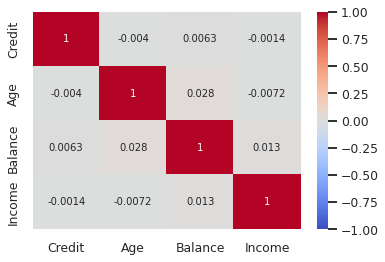

```python
# Correlation of numerical variables
heatmap = sns.heatmap(df.corr(), vmin=-1, vmax=1, annot=True, cmap="coolwarm")
heatmap;
```

There is no correlation between the numerical variables

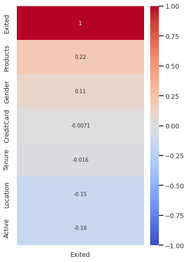

```python
# Visualizing categorical correlations to the target variable
fig = plt.figure(figsize=(5, 7), constrained_layout=True)
spec = fig.add_gridspec(1, 1)
ax1 = fig.add_subplot(spec[0, 0])

# Creating seperate df for categorical variables only
df_cat = df[cat_cols]

# Assigning the heatmap function to variable
heatmap = sns.heatmap(
    df_cat.apply(lambda x: pd.factorize(x)[0])
    .corr(method="pearson", min_periods=1)[["Exited"]]
    .sort_values(by="Exited", ascending=False),
    vmin=-1,
    vmax=1,
    annot=True,
    cmap="coolwarm",
)
heatmap;
```

Observations:

- There are some mild positive correlations between the number of products and gender and leaving the bank
- There are some mild negative correlations between activity and location and leaving the bank
- There is no readily apparent correlation between credit card or tenure and leaving the bank

**Target Variable Analysis**

```python
# function to plot distributions sorted by target variable
def distribution_plot_target(data, predictor, target):

    fig, axs = plt.subplots(2, 2, figsize=(12, 10))

    target_uniq = data[target].unique()

    axs[0, 0].set_title("Distribution of target for target=" + str(target_uniq[0]))
    sns.histplot(
        data=data[data[target] == target_uniq[0]],
        x=predictor,
        kde=True,
        ax=axs[0, 0],
        color="teal",
        stat="density",
    )

    axs[0, 1].set_title("Distribution of target for target=" + str(target_uniq[1]))
    sns.histplot(
        data=data[data[target] == target_uniq[1]],
        x=predictor,
        kde=True,
        ax=axs[0, 1],
        color="orange",
        stat="density",
    )

    axs[1, 0].set_title("Boxplot target")
    sns.boxplot(data=data, x=target, y=predictor, ax=axs[1, 0], palette="gist_rainbow")

    axs[1, 1].set_title("Boxplot (without outliers) target")
    sns.boxplot(
        data=data,
        x=target,
        y=predictor,
        ax=axs[1, 1],
        showfliers=False,
        palette="gist_rainbow",
    )

    plt.tight_layout()
    plt.show()
```

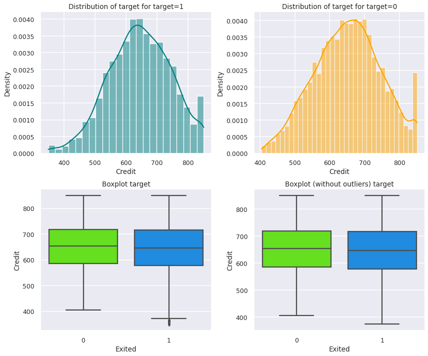

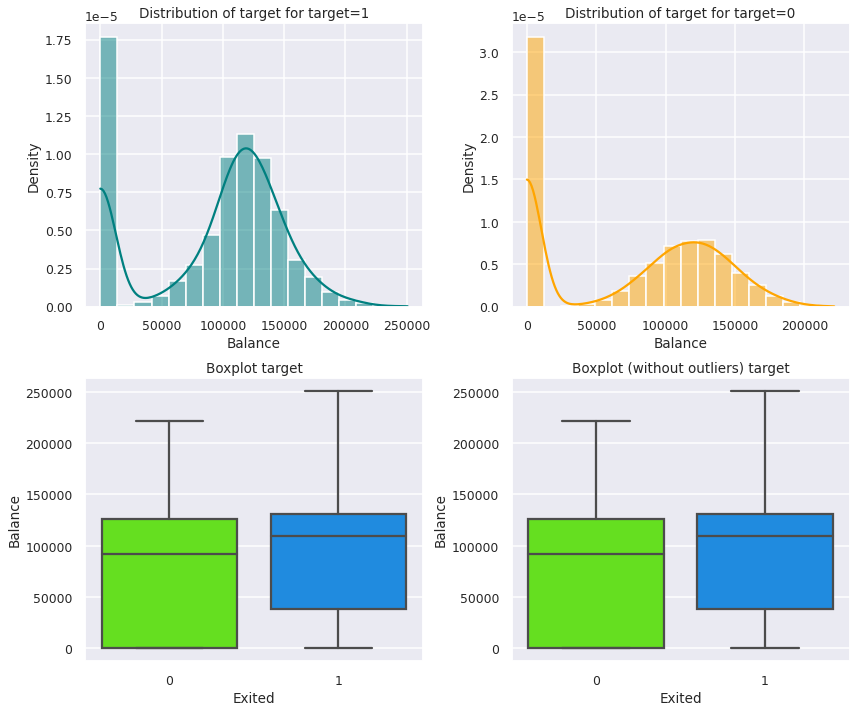

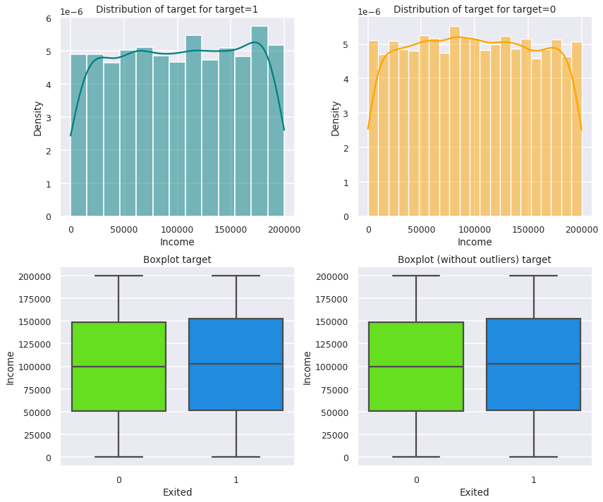

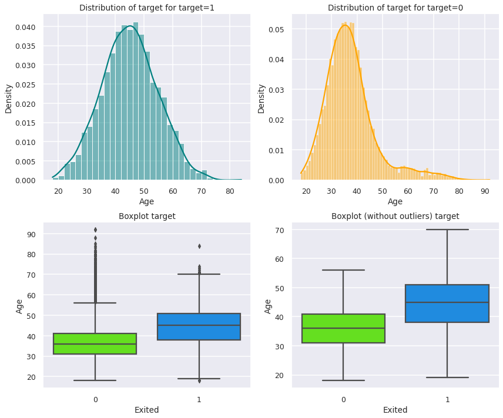

```python
for i in df[num_cols]:
  distribution_plot_target(data=df, predictor=i, target="Exited")
```

The only variable with readily apparent significance to our target variable is age. Those who have left the bank in the last six months are, on average, 10 years olders than those who have stayed (around 45)

```python
# function to plot stacked bar chart
def stacked_barplot(data, predictor, target):
    """
    Print the category counts and plot a stacked bar chart

    data: dataframe
    predictor: independent variable
    target: target variable
    """
    count = data[predictor].nunique()
    sorter = data[target].value_counts().index[-1]
    tab1 = pd.crosstab(data[predictor], data[target], margins=True).sort_values(
        by=sorter, ascending=False
    )
    print(tab1)
    print("-" * 120)
    tab = pd.crosstab(data[predictor], data[target], normalize="index").sort_values(
        by=sorter, ascending=False
    )
    tab.plot(kind="bar", stacked=True, figsize=(count + 5, 6))
    plt.legend(
        loc="lower left", frameon=False,
    )
    plt.legend(loc="upper left", bbox_to_anchor=(1, 1))
    plt.show()
```

```
Exited       0     1    All
Location
All       7963  2037  10000
Germany   1695   814   2509
France    4204   810   5014
Spain     2064   413   2477
------------------------------------------------------------------------------------------------------------------------
```

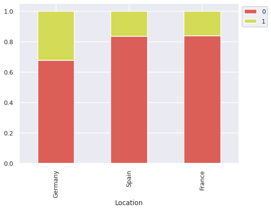

```
Exited     0     1    All
Gender
All     7963  2037  10000
Female  3404  1139   4543
Male    4559   898   5457
------------------------------------------------------------------------------------------------------------------------
```

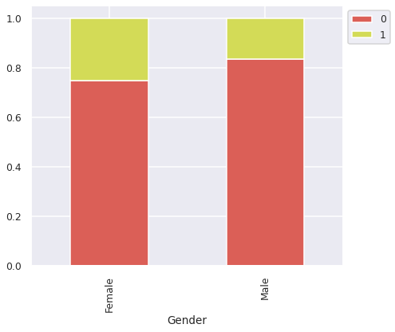

```
Exited     0     1    All
Tenure
All     7963  2037  10000
1        803   232   1035
3        796   213   1009
9        771   213    984
5        803   209   1012
4        786   203    989
2        847   201   1048
8        828   197   1025
6        771   196    967
7        851   177   1028
10       389   101    490
0        318    95    413
------------------------------------------------------------------------------------------------------------------------
```

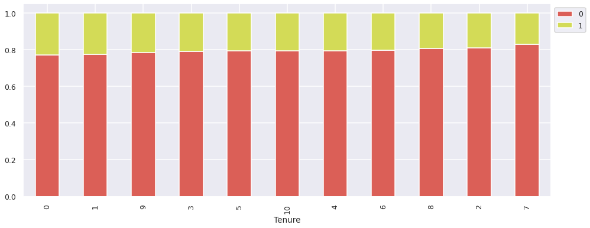

```
Exited       0     1    All
Products
All       7963  2037  10000
1         3675  1409   5084
2         4242   348   4590
3           46   220    266
4            0    60     60
------------------------------------------------------------------------------------------------------------------------
```

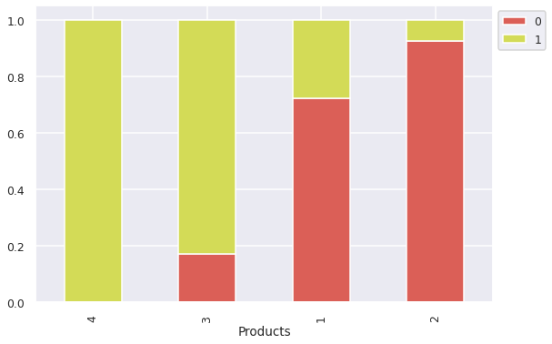

```
Exited         0     1    All
CreditCard
All         7963  2037  10000
1           5631  1424   7055
0           2332   613   2945
------------------------------------------------------------------------------------------------------------------------
```

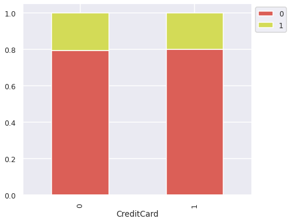

```
Exited     0     1    All
Active
All     7963  2037  10000
0       3547  1302   4849
1       4416   735   5151
------------------------------------------------------------------------------------------------------------------------
```

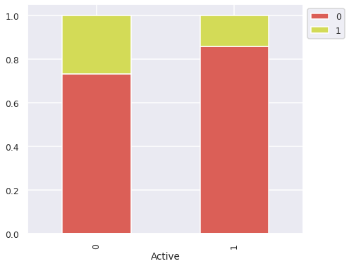

```
Exited     0     1    All
Exited
1          0  2037   2037
All     7963  2037  10000
0       7963     0   7963
------------------------------------------------------------------------------------------------------------------------
```

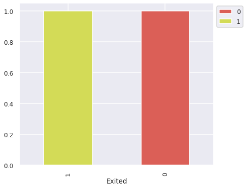

```python
for i in df[cat_cols]:
  stacked_barplot(data=df, predictor=i, target='Exited')
```

Observations:

### EDA & Data Cleaning Summary

**Data Cleaning Summary**

- Reformmated all column names
- Fixed all column dtypes
- Dropped Customer ID, Surname, and Row Number columns

### Data Pre-processing

```python
# Dropping variables that will not add value to the modeling process
df_model = df.drop(['Income', 'Tenure', 'CreditCard', 'Credit'], axis=1)

# Splitting the data into dependant and independant variables
x = df_model.drop(['Exited'],axis=1)
y = df_model[['Exited']]

# Splitting data into temporary and testing sets
x_temp, x_test, y_temp, y_test = train_test_split(x, y, test_size=0.2, random_state=1, stratify=y, shuffle=True)

# Splitting temporary into training and validation sets
x_train, x_val, y_train, y_val = train_test_split(x_temp, y_temp, test_size=0.3, random_state=1, stratify=y_temp, shuffle=True)
```

```python
# Removing redundant variables from cat_cols and num_cols
cat_cols_remove = ['Exited', 'CreditCard', 'Tenure']
cat_cols = list(set(cat_cols) - set(cat_cols_remove))

num_cols_remove = ['Credit', 'Income']
num_cols = list(set(num_cols) - set(num_cols_remove))

# Scaling the data
sc=StandardScaler()
temp = sc.fit(x_train[num_cols])
x_train[num_cols] = temp.transform(x_train[num_cols])
x_val[num_cols] = temp.transform(x_val[num_cols])
x_test[num_cols] = temp.transform(x_test[num_cols])

# OHE categorical variables
x_train = pd.get_dummies(x_train,columns=cat_cols,drop_first= True)
x_val = pd.get_dummies(x_val,columns=cat_cols,drop_first= True)
x_test = pd.get_dummies(x_test,columns=cat_cols,drop_first= True)
```

```python
# Checking the shape for each data split
print(x_train.shape)
print(x_val.shape)
print(x_test.shape)
```

```
(5600, 9)
(2400, 9)
(2000, 9)
```

**Data Pre-Processing Summary**

- Split data into temporary and testing sets (80/20 split)
  - Temporary data was further split into training and validation sets (70/30 split)
- Numerical data was scaled and categorical data was OHE

**Model Evaluation Criterion** Which loss is more detrimental to the bank?

1. Labeling a customer as leaving, but they will actually stay
2. Labeling a customer as staying, but the will actually leave

Since the goal is reduce attrition, misidentifying customers as wanting to continue their service, but that will actually cancel service needs to minimized. i.e. The number of false negatives needs to be reduced as much as possible. Therefore, the desired metric is recall.